# Party Differences

2023-08-08

Required packages

```r
require("ggplot2")
require("dplyr")
require("purrr")
require("tidyr")
require("readr")
require("haven")
require("tidyselect")
require("FDRestimation")
require(ggcorrplot)
require(gt)
require(gtExtras)
require(webshot2)
```

Importing data and creating new Likert-only dataset

```r
#Import dataset
data1 <- read_dta("~/Downloads/Valid dataset_book.dta")
data1<-zap_labels(data1)
head(data1)
```

```
## # A tibble: 6 × 159
##   source index totalseconds reward Q2_leadership Q2_law Q2_implementation
##   <chr>  <chr>        <dbl>  <dbl>         <dbl>  <dbl>             <dbl>
## 1 SAC    133            401      1             4      4                 4
## 2 SAB    205            407      5             5      5                 5
## 3 SAB    311            429      1             5      5                 5
## 4 SAB    560            435      1             5      5                 5
## 5 SAB    325            454      1             5      5                 5
## 6 SAB    107            461      5             4      4                 5
## # ℹ 152 more variables: Q2_design <dbl>, Q2_supervision <dbl>, Q2_ccp <dbl>,
## #   Q2_cadre <dbl>, Q2_SOE <dbl>, Q2_flexible <dbl>, Q2_grassdemocracy <dbl>,
## #   Q2_entreparticipant <dbl>, Q2_innerdemocracy <dbl>,
## #   Q2_citizenparticipant <dbl>, Q2_enterprises <dbl>, Q4_highlevel <dbl>,
## #   Q4_superior <dbl>, Q4_inspection <dbl>, Q4_people <dbl>, Q4_lpc <dbl>,
## #   Q4_lpcc <dbl>, Q4_newsmedia <dbl>, Q4_expert <dbl>, Q5_innovate <dbl>,
## #   Q5_autonomy <dbl>, Q5_dmdinnovation <dbl>, Q5_central <dbl>, …
```

```r
#New dataset with likert variables only
function1<-function(j){if(max(j)==5){return (TRUE)} else {return (FALSE)}} #keep variables with max of 5
data_likert<-data1 %>% dplyr::select(where(is.numeric)) %>% keep(function1)
head(data_likert)
```

```
## # A tibble: 6 × 82
##   Q2_leadership Q2_law Q2_implementation Q2_design Q2_supervision Q2_ccp
##           <dbl>  <dbl>             <dbl>     <dbl>          <dbl>  <dbl>
## 1             4      4                 4         5              5      4
## 2             5      5                 5         5              5      5
## 3             5      5                 5         5              5      5
## 4             5      5                 5         5              5      5
## 5             5      5                 5         5              4      5
## 6             4      4                 5         4              5      4
## # ℹ 76 more variables: Q2_cadre <dbl>, Q2_SOE <dbl>, Q2_flexible <dbl>,
## #   Q2_grassdemocracy <dbl>, Q2_entreparticipant <dbl>,
## #   Q2_innerdemocracy <dbl>, Q2_citizenparticipant <dbl>, Q2_enterprises <dbl>,
## #   Q5_innovate <dbl>, Q5_autonomy <dbl>, Q5_dmdinnovation <dbl>,
## #   Q5_central <dbl>, Q5_citizen <dbl>, Q5_experts <dbl>, E1N_30 <dbl>,
## #   E1N_50 <dbl>, E1N_70 <dbl>, E1T_30 <dbl>, E1T_50 <dbl>, E1T_70 <dbl>,
## #   E2_implementation <dbl>, Q15_disagree <dbl>, Q15_infochannel <dbl>, …
```

This code generates univariate histograms for all the Likert variables in the dataset. It confirms that while some of the variables approximate a normal distribution, none are very normal and many are very skewed. The plot is not printed here as it is too large.

```
#likert variables
data1 %>% dplyr::select(where(is.numeric)) %>% keep(function1) %>% gather(factor_key=TRUE) %>% ggplot(aes(value))+geom_bar()+facet_wrap(~key, scales="free")
```

Similar graph for non-Likert numeric variables.

```
#non-likert variables
function2<-function(j){if(max(j)<5){return (TRUE)} else {return (FALSE)}}
data1 %>% dplyr::select(where(is.numeric)) %>% keep(function2) %>% gather(factor_key=TRUE) %>% ggplot(aes(value))+geom_bar()+facet_wrap(~key, scales="free")
```

This is a quick correlation plot to investigate multi-colinearity. Variables that are highly correlated are co-linear, which can be problematic for parametric analysis methods. By visual inspection, correlation is fairly low.

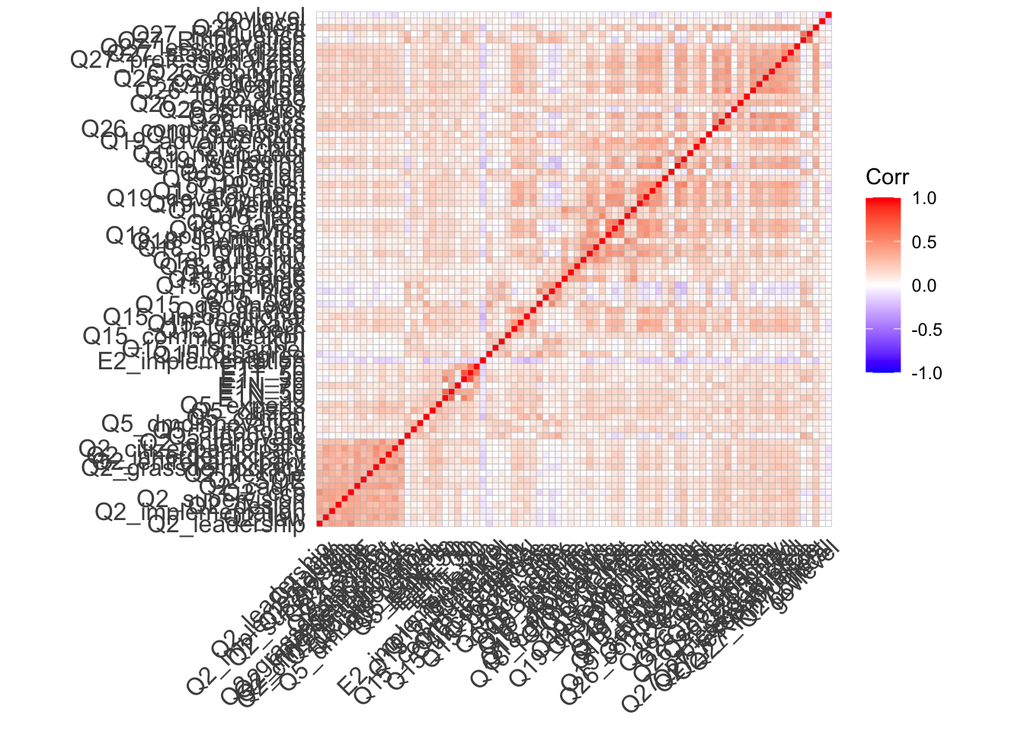

```r
cor_data<-cor(data_likert)
ggcorrplot(cor_data)
```

Creating a binary variable for CCP vs Others

```r
#(CCP=1, NON=all others)
party<-rep(NA, length(data_likert))
for(i in 1:length(data_likert$political)){
  if (data_likert$political[i]==1) {party[i]<-"CCP"} else {party[i]<-"Other"}
}
party<-as.factor(party)
data_likert$party<-party
data_likert$party<-as.factor(party)
head(data_likert$party)
```

```
## [1] Other Other Other Other Other Other
## Levels: CCP Other
```

This is code to check the question means for CCP and Other categories. By visual inspection, most are similar.

```r
#Checking that means vary by party
#By visual inspection means are very close
mean_check<-data_likert %>% group_by(party) %>% summarise(across(everything(), list(mean)))
head(mean_check)
```

```
## # A tibble: 2 × 83
##   party Q2_leadership_1 Q2_law_1 Q2_implementation_1 Q2_design_1
##   <fct>           <dbl>    <dbl>               <dbl>       <dbl>
## 1 CCP              4.51     4.63                4.45        4.33
## 2 Other            4.49     4.53                4.54        4.38
## # ℹ 78 more variables: Q2_supervision_1 <dbl>, Q2_ccp_1 <dbl>,
## #   Q2_cadre_1 <dbl>, Q2_SOE_1 <dbl>, Q2_flexible_1 <dbl>,
## #   Q2_grassdemocracy_1 <dbl>, Q2_entreparticipant_1 <dbl>,
## #   Q2_innerdemocracy_1 <dbl>, Q2_citizenparticipant_1 <dbl>,
## #   Q2_enterprises_1 <dbl>, Q5_innovate_1 <dbl>, Q5_autonomy_1 <dbl>,
## #   Q5_dmdinnovation_1 <dbl>, Q5_central_1 <dbl>, Q5_citizen_1 <dbl>,
## #   Q5_experts_1 <dbl>, E1N_30_1 <dbl>, E1N_50_1 <dbl>, E1N_70_1 <dbl>, …
```

T Test:

A Student’s T Test determines whether the means of two populations are statistically different.  
A T test makes several assumptions: the data is continuous, the sample is taken randomly, and the data is distributed approximately normally. The default T Test in R does not assume that sample variances are the same size. This data is not continuous or normal, which limits the validity of the results.  
A sample of the results are displayed below.

```r
#t.test model
modelname<-lapply(paste(colnames(data_likert[,-83]), "~ party"), as.formula)
function3<-function(x) {
  y<-t.test(x, data =data_likert)
  p<-y$p.value
  meanccp<-y$estimate[[1]]
  meanother<-y$estimate[[2]]
  lower<-y$conf.int[[1]]
  upper<-y$conf.int[[2]]
  return(c(meanccp, meanother, lower, upper, p))
  }
t_results<-lapply(modelname, function3)
t_results<-t(as.data.frame(t_results))
rownames(t_results)<-colnames(data_likert[,-83])
#Adjusting p-values using Benjamini-Hochberg method (default alpha=0.05)
t_results[,5]<-p.fdr(pvalues=t_results[,5])$`Results Matrix`[[2]]
colnames(t_results)<-c("mean_ccp", "mean_other", "conf_lower", "conf_upper", "p-value")
head(t_results)
```

```
##                   mean_ccp mean_other    conf_lower    conf_upper    p-value
## Q2_leadership     4.506092   4.489130 -0.0803299614  0.1142527844 0.80052346
## Q2_law            4.626054   4.532609 -0.0006464830  0.1875378078 0.10575841
## Q2_implementation 4.447985   4.540761 -0.1815319795 -0.0040197503 0.09469229
## Q2_design         4.328022   4.383152 -0.1549188476  0.0446594857 0.42029500
## Q2_supervision    4.379569   4.475543 -0.1911681532 -0.0007810339 0.10391427
## Q2_ccp            4.707591   4.622283 -0.0004823462  0.1710998842 0.10575841
```

The function below performs a regression for each variable with party affiliation as the predictor. This provides insight into which parties answer differently from the CCP.  
A factor regression assumes a linear relationship between explanatory and outcome variables as well as normality, little multicolinearity, and constant variance. As mentioned above, the data is often not normally distributed, and there are likely some problems with colinearity.  
A Benjamini-Hochstein correction for multiple testing is used to adjust the p-value as well.

```r
#lm model
modelname1<-lapply(paste(colnames(data_likert[,-83]), "~ as.factor(political)"), as.formula)
function4<-function(x) {
  y<-lm(x, data =data_likert)
  intercept<-y$coefficients[[1]]
  p0<-summary(y)$coefficients[1,4]
  pol2<-y$coefficients[[2]]
  p2<-summary(y)$coefficients[2,4]
  pol3<-y$coefficients[[3]]
  p3<-summary(y)$coefficients[3,4]
  pol4<-y$coefficients[[4]]
  p4<-summary(y)$coefficients[4,4]
  pol5<-y$coefficients[[5]]
  p5<-summary(y)$coefficients[5,4]
  return(c(intercept, p0, pol2, p2, pol3, p3, pol4, p4, pol5, p5))
}
lm_results<-lapply(modelname1, function4)
lm_results<-t(as.data.frame(lm_results))
#Benjamini-Hochberg Adjusting p-values (alpha=0.05)
lm_results[,4]<-p.fdr(pvalues=lm_results[,4])$`Results Matrix`[[2]]
lm_results[,6]<-p.fdr(pvalues=lm_results[,6])$`Results Matrix`[[2]]
lm_results[,8]<-p.fdr(pvalues=lm_results[,8])$`Results Matrix`[[2]]
lm_results[,10]<-p.fdr(pvalues=lm_results[,10])$`Results Matrix`[[2]]
colnames(lm_results)<-c("CCP_slope", "ccp_p", "CCP_applicant", "applicant_p", "demo", "dem_p", "none", "none_p", "masses", "masses_p")
rownames(lm_results)<-colnames(data_likert[,-83])
head(lm_results)
```

```
##                   CCP_slope ccp_p CCP_applicant applicant_p        demo
## Q2_leadership      4.506092     0  -0.002823872   0.9781730 -0.06164740
## Q2_law             4.626054     0  -0.109714489   0.3411621 -0.40383214
## Q2_implementation  4.447985     0   0.114106499   0.3411621  0.10757055
## Q2_design          4.328022     0  -0.053512689   0.7030578  0.00531084
## Q2_supervision     4.379569     0   0.038731769   0.7793008 -0.15734666
## Q2_ccp             4.707591     0   0.011362871   0.9385137 -0.59648027
##                       dem_p        none    none_p      masses   masses_p
## Q2_leadership     0.9483737 -0.10609185 0.7680395 -0.01918085 0.84804590
## Q2_law            0.6141381 -0.02605436 0.9393454 -0.07108054 0.30743251
## Q2_implementation 0.8827808  0.15201500 0.6466341  0.07033960 0.32781187
## Q2_design         0.9954654  0.27197751 0.4805057  0.12747489 0.11576516
## Q2_supervision    0.8780745  0.42043112 0.1899279  0.12828452 0.08133114
## Q2_ccp            0.2449716 -0.10759138 0.7073614 -0.13691075 0.03340257
```

Table of all questions that have significantly different mean responses by party.

```r
table1<-as.data.frame(cbind(t_results, lm_results))
table1<-table1[,-c(3, 4)] #remove confidence interval
vars<- ifelse(table1[,3]<=0.05 | table1[,7]<=0.05 | table1[,9]<=0.05 | table1[,11]<=0.05 | table1[,13]<=0.05, 1, 0) #Column is 1 for significant questions
table1<-table1 %>% filter(vars==1)
table1<-gt(as.data.frame(table1), rownames_to_stub = TRUE)
table1<-
  table1 |>
  tab_header( title="Difference in Response by Party") |>
  tab_source_note(source_note="Key: Highlighted cells are significant. P-Values have been Bejamini-Hochberg corrected.")|>
  tab_source_note(source_note= "For the factor regression, CCP is the baseline.Small p-values indicate that the mean responses from that party differ from the mean CCP response.") |>
  tab_stubhead(label="Question") |>
  tab_spanner(label="Student's T-Test", columns=c("mean_ccp", "mean_other", "p-value")) |>
  tab_spanner(label="Regression as Factor", columns=c("CCP_slope", "ccp_p", "CCP_applicant", "applicant_p","demo", "dem_p", "none", "none_p", "masses", "masses_p")) |>
  cols_label(mean_ccp="CCP Mean", mean_other="Other Party Mean", `p-value`="P-Value", CCP_slope="Intercept (CCP)", ccp_p="Intercept P-Value", CCP_applicant="CCP Applicant", applicant_p="Applicant P-Value", demo="Democratic Party", dem_p="Democratic Party P-Value", none="No Party", none_p="No Party P-Value", masses="Masses", masses_p="Masses P-Value")|>
  fmt_number(columns=everything(), rows=everything(), decimals=5)|> tab_style(style=list(cell_fill(color="lightblue")), locations=cells_body(columns=c(mean_ccp, mean_other, `p-value`), rows=`p-value`<0.025))|>
  tab_style(style=list(cell_fill(color="lightblue")), locations=cells_body(columns=c(CCP_applicant, applicant_p), rows=applicant_p<0.025))|>
  tab_style(style=list(cell_fill(color="lightblue")), locations=cells_body(columns=c(demo, dem_p), rows=dem_p<0.025))|>
  tab_style(style=list(cell_fill(color="lightblue")), locations=cells_body(columns=c(none, none_p), rows=none_p<0.025))|>
  tab_style(style=list(cell_fill(color="lightblue")), locations=cells_body(columns=c(masses, masses_p), rows=masses_p<0.025))
table1
```

Difference in Response by Party

| Question | Student's T-Test CCP Mean | Student's T-Test Other Party Mean | Student's T-Test P-Value | Regression as Factor Intercept (CCP) | Regression as Factor Intercept P-Value | Regression as Factor CCP Applicant | Regression as Factor Applicant P-Value | Regression as Factor Democratic Party | Regression as Factor Democratic Party P-Value | Regression as Factor No Party | Regression as Factor No Party P-Value | Regression as Factor Masses | Regression as Factor Masses P-Value |
| --- | --- | --- | --- | --- | --- | --- | --- | --- | --- | --- | --- | --- | --- |
| Q2_ccp | 4.70759 | 4.62228 | 0.10576 | 4.70759 | 0.00000 | 0.01136 | 0.93851 | −0.59648 | 0.24497 | −0.10759 | 0.70736 | −0.13691 | 0.03340 |
| Q2_SOE | 4.06279 | 4.10598 | 0.55660 | 4.06279 | 0.00000 | −0.12162 | 0.40553 | −0.17390 | 0.87807 | 0.20387 | 0.64102 | 0.17281 | 0.03837 |
| Q2_grassdemocracy | 4.17901 | 4.32609 | 0.03078 | 4.17901 | 0.00000 | 0.06936 | 0.64401 | 0.04322 | 0.96615 | 0.02099 | 0.94926 | 0.22413 | 0.01106 |
| Q2_enterprises | 3.69260 | 3.81793 | 0.08511 | 3.69260 | 0.00000 | −0.02593 | 0.91135 | 0.08518 | 0.94104 | 0.44074 | 0.28136 | 0.22363 | 0.01314 |
| Q5_innovate | 3.45923 | 3.65217 | 0.01716 | 3.45923 | 0.00000 | −0.02786 | 0.92226 | −0.23701 | 0.87244 | 0.40744 | 0.42054 | 0.37323 | 0.00026 |
| Q5_central | 2.83224 | 3.11685 | 0.00163 | 2.83224 | 0.00000 | 0.20698 | 0.25714 | −0.05446 | 0.96615 | 0.50109 | 0.36081 | 0.34577 | 0.00246 |
| Q5_citizen | 4.01312 | 4.19022 | 0.00482 | 4.01312 | 0.00000 | 0.11760 | 0.41901 | 0.32021 | 0.78679 | 0.18688 | 0.64527 | 0.21725 | 0.01039 |
| E1N_30 | 2.74039 | 3.17391 | 0.00000 | 2.74039 | 0.00000 | 0.42954 | 0.00067 | 0.81516 | 0.52095 | −0.07373 | 0.90882 | 0.45856 | 0.00001 |
| E1N_50 | 3.64292 | 3.85598 | 0.00086 | 3.64292 | 0.00000 | 0.20021 | 0.06196 | 0.69041 | 0.38390 | 0.15708 | 0.67155 | 0.20524 | 0.01261 |
| E1T_30 | 2.69541 | 3.10326 | 0.00001 | 2.69541 | 0.00000 | 0.21962 | 0.24702 | 1.19348 | 0.22931 | 0.57126 | 0.28696 | 0.50878 | 0.00001 |
| E1T_50 | 3.35426 | 3.58967 | 0.00217 | 3.35426 | 0.00000 | 0.09672 | 0.61002 | 0.42351 | 0.78679 | 0.64574 | 0.17818 | 0.30542 | 0.00227 |
| Q15_disagree | 2.73290 | 2.93478 | 0.00610 | 2.73290 | 0.00000 | 0.12985 | 0.43623 | 0.15599 | 0.88278 | 0.66710 | 0.17818 | 0.22522 | 0.01731 |
| Q15_goodnews | 2.21649 | 2.56250 | 0.00024 | 2.21649 | 0.00000 | 0.34560 | 0.02061 | 0.78351 | 0.54257 | 0.51684 | 0.36081 | 0.31230 | 0.01039 |
| Q15_hide | 2.97470 | 3.23098 | 0.00192 | 2.97470 | 0.00000 | 0.28021 | 0.03860 | 0.46975 | 0.78628 | 0.35864 | 0.48051 | 0.21902 | 0.04249 |
| Q18_income | 3.61949 | 3.85598 | 0.00025 | 3.61949 | 0.00000 | 0.11253 | 0.46619 | 0.60273 | 0.52925 | 0.58051 | 0.17818 | 0.29150 | 0.00080 |
| Q18_authority | 2.92690 | 3.10598 | 0.03186 | 2.92690 | 0.00000 | 0.12539 | 0.47469 | 0.51755 | 0.66235 | 0.87310 | 0.08099 | 0.15164 | 0.14310 |
| Q18_fun | 3.20337 | 3.47826 | 0.00093 | 3.20337 | 0.00000 | 0.24761 | 0.10134 | 0.12996 | 0.90537 | 0.52996 | 0.28286 | 0.28354 | 0.01039 |
| Q18_shorthours | 2.88754 | 3.33696 | 0.00000 | 2.88754 | 0.00000 | 0.35429 | 0.00593 | 0.44580 | 0.78679 | 0.24580 | 0.64527 | 0.54178 | 0.00000 |
| Q18_free | 3.32427 | 3.66848 | 0.00001 | 3.32427 | 0.00000 | 0.39468 | 0.00142 | 0.67573 | 0.54257 | 0.40906 | 0.42054 | 0.28306 | 0.00978 |
| Q18_welfare | 3.81068 | 4.08967 | 0.00005 | 3.81068 | 0.00000 | 0.27428 | 0.02061 | −0.25513 | 0.86816 | 0.52265 | 0.20262 | 0.28879 | 0.00246 |
| Q19_payment | 3.61293 | 3.78533 | 0.03414 | 3.61293 | 0.00000 | 0.13216 | 0.46619 | −0.39071 | 0.78679 | 0.05373 | 0.91868 | 0.24047 | 0.01917 |
| Q19_resign | 2.73477 | 3.05435 | 0.00057 | 2.73477 | 0.00000 | 0.11490 | 0.61353 | 0.59856 | 0.66235 | 0.39856 | 0.48998 | 0.46418 | 0.00006 |
| Q19_child | 3.59231 | 3.85326 | 0.00093 | 3.59231 | 0.00000 | 0.33579 | 0.00762 | −0.25898 | 0.86816 | −0.05898 | 0.91832 | 0.25062 | 0.01731 |
| Q19_demotion | 3.17338 | 3.34783 | 0.04029 | 3.17338 | 0.00000 | 0.02270 | 0.93851 | 0.82662 | 0.52095 | 0.69328 | 0.17818 | 0.22452 | 0.03837 |
| Q26_colleagues | 3.88566 | 4.00272 | 0.08367 | 3.88566 | 0.00000 | −0.03599 | 0.82321 | 0.55878 | 0.52925 | 0.44767 | 0.19707 | 0.19287 | 0.01731 |
| Q26_veto | 4.04217 | 4.11957 | 0.29148 | 4.04217 | 0.00000 | −0.07485 | 0.61614 | 0.06894 | 0.94837 | 0.35783 | 0.39903 | 0.17772 | 0.04274 |
| Q26_degree | 3.74695 | 3.96739 | 0.00163 | 3.74695 | 0.00000 | 0.26612 | 0.02061 | 0.25305 | 0.86816 | −0.21362 | 0.64527 | 0.21640 | 0.02059 |
| Q26_party | 3.79850 | 4.11413 | 0.00000 | 3.79850 | 0.00000 | 0.20150 | 0.11471 | −0.02072 | 0.99547 | 0.53483 | 0.18993 | 0.40569 | 0.00000 |
| Q27_Rinnovation | 3.14433 | 3.47011 | 0.00002 | 3.14433 | 0.00000 | 0.12364 | 0.49560 | 0.74456 | 0.52925 | 0.25567 | 0.64262 | 0.47347 | 0.00000 |
| Q27_Rinfluence | 3.37863 | 3.57337 | 0.00934 | 3.37863 | 0.00000 | 0.20307 | 0.14979 | 0.51026 | 0.66235 | 0.02137 | 0.94926 | 0.18681 | 0.06134 |
| political | 1.00000 | 3.66304 | 0.00000 | 1.00000 | 0.00000 | 1.00000 | 0.00000 | 2.00000 | 0.00000 | 3.00000 | 0.00000 | 4.00000 | 0.00000 |
| govlevel | 2.30084 | 1.91848 | 0.00000 | 2.30084 | 0.00000 | −0.39235 | 0.00002 | 0.14360 | 0.88278 | −0.10084 | 0.80441 | −0.42126 | 0.00000 |

Key: Highlighted cells are significant. P-Values have been Bejamini-Hochberg corrected.  
For the factor regression, CCP is the baseline.Small p-values indicate that the mean responses from that party differ from the mean CCP response.

```r
#gtsave(table1, 'partydifferences.png', vwidth=1500, vheight=1000) <-Will save table as png file
```

```r
e1n<-c("E1N_30", "E1N_50", "E1N_70")
table3<-as.data.frame(cbind(t_results, lm_results))
tablen<-table3 %>% filter(rownames(table3) %in% e1n)
rownames(tablen)<-c("30%", "50%", "70%")
View(tablen)
tablen<-tablen[,-c(3, 4)]
tablen<-gt(as.data.frame(tablen), rownames_to_stub = TRUE)
tablen<-
  tablen |>
  tab_header( title="Party Difference in Risk Affinity", subtitle="What is your willingness to carry out a reform given its probability of success?") |>
  tab_source_note(source_note= "Key: Highlighted cells are significant. P-Values have been Benjamini-Hochstein corrected.") |>
  tab_source_note(source_note= "In the factor regression, CCP is the baseline. The coefficient estimates indicate how mean responses from that party differ from the mean CCP response.") |>
  tab_stubhead(label="Chance of Success") |>
  tab_spanner(label="Student's T-Test", columns=c("mean_ccp", "mean_other", "p-value")) |>
  tab_spanner(label="Regression as Factor", columns=c("CCP_slope", "ccp_p", "CCP_applicant", "applicant_p", "demo", "dem_p", "none", "none_p", "masses", "masses_p")) |>
  cols_label(mean_ccp="CCP Mean", mean_other="Non-CCP Mean", 'p-value'="P-Value", CCP_slope="Intercept (CCP)",
             ccp_p="Intercept P-Value", CCP_applicant="CCP Applicant", applicant_p="CCP Applicant P-Value",demo="Democratic Party",
             dem_p="Democratic Party P-Value", none="No Party", none_p="No Party P-Value", masses="Masses", masses_p="Masses P-Value")|>
        fmt_number(columns=everything(), rows=everything(), decimals=5)|>
  tab_style(style=list(cell_fill(color="lightblue")), locations=cells_body(columns=c(mean_ccp, mean_other, `p-value`), rows=`p-value`<0.025))|>
  tab_style(style=list(cell_fill(color="lightblue")), locations=cells_body(columns=c(CCP_applicant, applicant_p), rows=applicant_p<0.025))|>
  tab_style(style=list(cell_fill(color="lightblue")), locations=cells_body(columns=c(demo, dem_p), rows=dem_p<0.025))|>
  tab_style(style=list(cell_fill(color="lightblue")), locations=cells_body(columns=c(none, none_p), rows=none_p<0.025))|>
  tab_style(style=list(cell_fill(color="lightblue")), locations=cells_body(columns=c(masses, masses_p), rows=masses_p<0.025))|>
  tab_style(style=cell_text(weight="bold"), locations=cells_column_labels())|>
  tab_style(style=cell_text(weight="bold"), locations=cells_stub())
tablen
```

Party Difference in Risk Affinity

What is your willingness to carry out a reform given its probability of success?

| Chance of Success | Student's T-Test CCP Mean | Student's T-Test Non-CCP Mean | Student's T-Test P-Value | Regression as Factor Intercept (CCP) | Regression as Factor Intercept P-Value | Regression as Factor CCP Applicant | Regression as Factor CCP Applicant P-Value | Regression as Factor Democratic Party | Regression as Factor Democratic Party P-Value | Regression as Factor No Party | Regression as Factor No Party P-Value | Regression as Factor Masses | Regression as Factor Masses P-Value |
| --- | --- | --- | --- | --- | --- | --- | --- | --- | --- | --- | --- | --- | --- |
| 30% | 2.74039 | 3.17391 | 0.00000 | 2.74039 | 0.00000 | 0.42954 | 0.00067 | 0.81516 | 0.52095 | −0.07373 | 0.90882 | 0.45856 | 0.00001 |
| 50% | 3.64292 | 3.85598 | 0.00086 | 3.64292 | 0.00000 | 0.20021 | 0.06196 | 0.69041 | 0.38390 | 0.15708 | 0.67155 | 0.20524 | 0.01261 |
| 70% | 4.44892 | 4.50815 | 0.31538 | 4.44892 | 0.00000 | 0.09356 | 0.45455 | −0.22670 | 0.81556 | 0.15108 | 0.64663 | 0.03799 | 0.62751 |

Key: Highlighted cells are significant. P-Values have been Benjamini-Hochstein corrected.  
In the factor regression, CCP is the baseline. The coefficient estimates indicate how mean responses from that party differ from the mean CCP response.

```r
#Option to save file: gtsave(tablen, 'ReformWillingness.png', vwidth=1500, vheight=1000)
```

```r
e1t<-c("E1T_30", "E1T_50", "E1T_70")
tablet<-table3 %>% filter(rownames(table3) %in% e1t)
rownames(tablet)<-c("30%", "50%", "70%")
View(tablet)
tablet<-tablet[,-c(3, 4)]
tablet<-gt(as.data.frame(tablet), rownames_to_stub = TRUE)
tablet<-
  tablet |>
  tab_header( title="Party Difference in Risk Affinity", subtitle="Were local cadres willing to carry out a reform 10 years ago given its probability of success?") |>
  tab_source_note(source_note= "Key: Highlighted cells are significant. P-Values have been Benjamini-Hochstein corrected.") |>
  tab_source_note(source_note= "In the factor regression, CCP is the baseline. The coefficient estimates indicate how mean responses from that party differ from the mean CCP response.") |>
  tab_stubhead(label="Chance of Success") |>
  tab_spanner(label="Student's T-Test", columns=c("mean_ccp", "mean_other", "p-value")) |>
  tab_spanner(label="Regression as Factor", columns=c("CCP_slope", "ccp_p", "CCP_applicant", "applicant_p", "demo", "dem_p", "none", "none_p", "masses", "masses_p")) |>
  cols_label(mean_ccp="CCP Mean", mean_other="Non-CCP Mean", 'p-value'="P-Value", CCP_slope="Intercept (CCP)",
             ccp_p="Intercept P-Value", CCP_applicant="CCP Applicant", applicant_p="CCP Applicant P-Value",demo="Democratic Party",
             dem_p="Democratic Party P-Value", none="No Party", none_p="No Party P-Value", masses="Masses", masses_p="Masses P-Value")|>
  fmt_number(columns=everything(), rows=everything(), decimals=5)|>
  tab_style(style=list(cell_fill(color="lightblue")), locations=cells_body(columns=c(mean_ccp, mean_other, `p-value`), rows=`p-value`<0.025))|>
  tab_style(style=list(cell_fill(color="lightblue")), locations=cells_body(columns=c(CCP_applicant, applicant_p), rows=applicant_p<0.025))|>
  tab_style(style=list(cell_fill(color="lightblue")), locations=cells_body(columns=c(demo, dem_p), rows=dem_p<0.025))|>
  tab_style(style=list(cell_fill(color="lightblue")), locations=cells_body(columns=c(none, none_p), rows=none_p<0.025))|>
  tab_style(style=list(cell_fill(color="lightblue")), locations=cells_body(columns=c(masses, masses_p), rows=masses_p<0.025))|>
  tab_style(style=cell_text(weight="bold"), locations=cells_column_labels())|>
  tab_style(style=cell_text(weight="bold"), locations=cells_stub())
tablet
```

Party Difference in Risk Affinity

Were local cadres willing to carry out a reform 10 years ago given its probability of success?

| Chance of Success | Student's T-Test CCP Mean | Student's T-Test Non-CCP Mean | Student's T-Test P-Value | Regression as Factor Intercept (CCP) | Regression as Factor Intercept P-Value | Regression as Factor CCP Applicant | Regression as Factor CCP Applicant P-Value | Regression as Factor Democratic Party | Regression as Factor Democratic Party P-Value | Regression as Factor No Party | Regression as Factor No Party P-Value | Regression as Factor Masses | Regression as Factor Masses P-Value |
| --- | --- | --- | --- | --- | --- | --- | --- | --- | --- | --- | --- | --- | --- |
| 30% | 2.69541 | 3.10326 | 0.00001 | 2.69541 | 0.00000 | 0.21962 | 0.24702 | 1.19348 | 0.22931 | 0.57126 | 0.28696 | 0.50878 | 0.00001 |
| 50% | 3.35426 | 3.58967 | 0.00217 | 3.35426 | 0.00000 | 0.09672 | 0.61002 | 0.42351 | 0.78679 | 0.64574 | 0.17818 | 0.30542 | 0.00227 |
| 70% | 4.06748 | 4.19293 | 0.08180 | 4.06748 | 0.00000 | 0.06978 | 0.64401 | 0.26585 | 0.85812 | 0.19919 | 0.64527 | 0.15765 | 0.07930 |

Key: Highlighted cells are significant. P-Values have been Benjamini-Hochstein corrected.  
In the factor regression, CCP is the baseline. The coefficient estimates indicate how mean responses from that party differ from the mean CCP response.

```r
#option to save file: gtsave(table1, 'partydifferences.png', vwidth=1500, vheight=1000)
```